# Cormack-Jolly-Seber Model with Dipper Data

### Dipper Cormack-Jolly-Seber (CJS) Model

The dipper model is a very common example CJS model. As used, for example, in [Turek et al. (2016)](https://link.springer.com/article/10.1007/s10651-016-0353-z), *Environmental and Ecological Statistics*.

The observational data consists binary 1’s and 0’s, representing observed (1), or not-observed (0). The data is for $N$ = 209 birds, over a period of $T$ = 7 years.

Of the $N$ = 209 birds, 101 are females, and 108 are males. Initially we’ll ignore gender, for simplicity, but we’ll use the gender information later.

The parameters of interest will be survival $\phi$, and probability of detection $p$. Both of these are assumed to be constant in our first model.

### Dipper Data

You can [download the dipper data here](https://danielturek.github.io/nimble-inra-2019/data/dipper_data.Rdata).

This file contains the variables:

- `sightings`: An $N$ = 209 by $T$ = 7 array, containing 1’s, 0’s and `NA`’s. Each row represents the sighting history of a unique bird. Each column is a different year. Leading `NA` values are observation periods before an individual was first observed.
- `first`: A vector of length $N$ = 209, where each entry gives the time period for which an individual was first seen. For example, individal #1 was first seen on time period 1, therefore `first[1] = 1`, whereas individual #13 was first seen on time period 2, therefore `first[13] = 2`.
- `gender`: A vector of length $N$ = 209, where each entry specifies the gender of a individual. 1’s correspond to females, and 2’s correspond to males.

### Fitting the dipper model

Let’s construct model code for the dipper CJS model.

Then, we’ll fit the model using NIMBLE’s MCMC.

In our model, we’ll use the following nodes:

- `phi`: Probability of survival
- `p`: Probability detection (capture) probability
- `x[i, t]`: Latent states representing true alive (1) or dead (0) status, for individual `i` at time `t`
- `y[i, t]` = Observed data for capture (1) or not-captured (0) for individual `i` at time `t`
- `first[i]` = Year of first capture for individual `i`

We’ll also have to take care to provide appropriate initial values for the `x` matrix.

```r
library(nimble)

load('~/Downloads/dipper_data.Rdata')

dipperCode <- nimbleCode({
    phi ~ dunif(0, 1)
    p ~ dunif(0, 1)
    for(i in 1:N) {
        x[i, first[i]] <- 1
        y[i, first[i]] <- 1
        for(t in (first[i]+1):T) {
            x[i, t] ~ dbern(phi * x[i, t-1])
            y[i, t] ~ dbern(p * x[i, t])
        }
    }
})

N <- dim(sightings)[1]
T <- dim(sightings)[2]

dipperConsts <- list(N = N, T = T, first = first)

dipperData <- list(y = sightings)

xInit <- ifelse(!is.na(sightings), 1, 0)

dipperInits <- list(phi = 0.5, p = 0.5, x = xInit)

Rmodel <- nimbleModel(dipperCode, dipperConsts, dipperData, dipperInits)

conf <- configureMCMC(Rmodel)
Rmcmc <- buildMCMC(conf)

Cmodel <- compileNimble(Rmodel)
Cmcmc <- compileNimble(Rmcmc, project = Rmodel)

set.seed(0)
samples <- runMCMC(Cmcmc, niter = 20000, nburnin = 10000)
```

### Results

Here are the results I got, for our first dipper CJS model:

```r
round(samplesSummary(samples), 3)
```

```
##      Mean Median St.Dev. 95%CI_low 95%CI_upp
## p   0.896  0.898   0.030     0.834     0.947
## phi 0.562  0.562   0.026     0.511     0.613
```

A visual inspection of the posterior distributions:

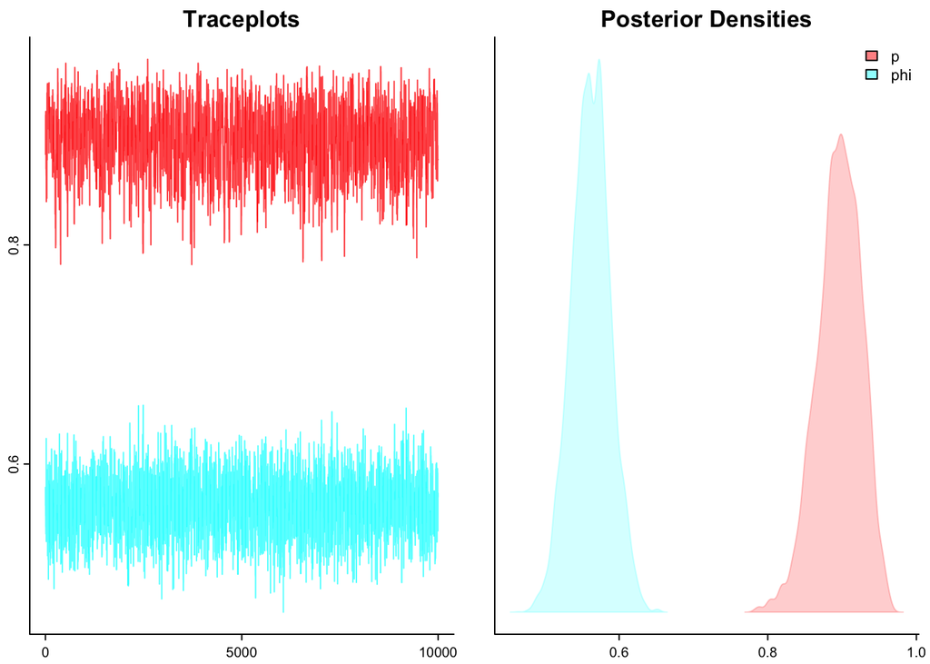

```r
library(basicMCMCplots)

basicMCMCplots::samplesPlot(samples)
```